# STA Honours Time Series: dlm prac

Author

Birgit Erni

Published

November 1, 2023

```r
library(dlm)
#library(fpp2)
```

# Introduction

Have a look at the dlm vignette.

dlm = dynamic linear model, basically a linear Gaussian state-space model. *Dynamic* refers to the property that the state will change over time.

# Random Walk plus Noise

To simulate values from a random walk plus noise model, V, W, m0 and C0 are needed.

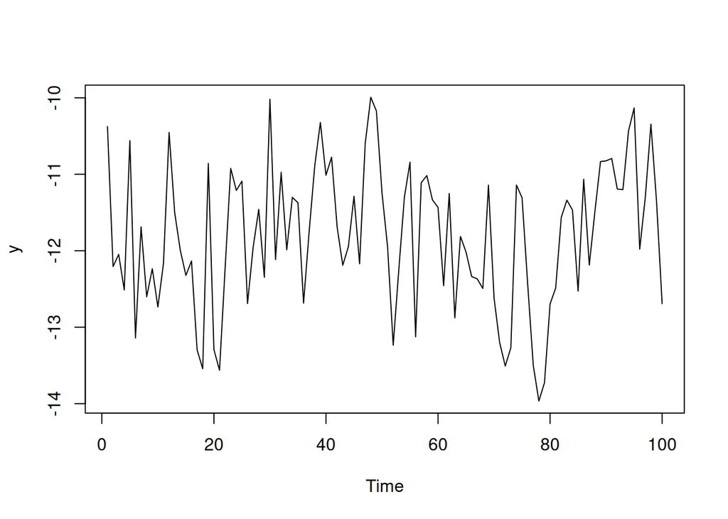

```r
rwpn <- function(V = 0.8, W = 0.2, m0 = 0, C0 = 100, n = 100) {

  y <- numeric(n)
  mu <- numeric(n)

  for (i in 1:n) {
    if (i == 1) mu[i] <- rnorm(1, m0, C0)
    else mu[i] <- rnorm(1, mu[i-1], W)
    y[i] <- rnorm(1, mu[i], V)
  }

  return(y)
}

y <- rwpn()

plot.ts(y)
```

## Define dlm model

For now we assume that the parameters are known. We have observations and want to estimate the state, and perhaps also predict future observations.

Start by defining the model. Here we define a random walk plus noise state-space model, through the matrices F and G. We also specify the parameters and the mean and variance of the prior (initial state) m0 and C0.

```r
## define model
mod.rwpn <- dlm(FF = 1, V = 0.8, GG = 1, W = 0.2, m0 = 0, C0 = 100)
```

An alternative, equivalent way to define this model is by using dlmModPoly

```r
dlmModPoly(order = 1, dV = 0.8, dW = 0.2, C0 = 100)
```

```
$FF
     [,1]
[1,]    1

$V
     [,1]
[1,]  0.8

$GG
     [,1]
[1,]    1

$W
     [,1]
[1,]  0.2

$m0
[1] 0

$C0
     [,1]
[1,]  100
```

Careful with the defaults of the above arguments. dV and dW refer to the *diagonal* elements of the V and W matrices.

`order = 1` means that the state follows a random walk. `order = 2` (second order polynomial) refers to a random walk plus drift model for the state. This terminology comes from the fact that if you would take 1st or 2nd order differences of the observations you would end up with a stationary process (tut question).

We have now defined the structure of the model, with all the familiar state space model matrices:

```r
mod.rwpn
```

```
$FF
     [,1]
[1,]    1

$V
     [,1]
[1,]  0.8

$GG
     [,1]
[1,]    1

$W
     [,1]
[1,]  0.2

$m0
[1] 0

$C0
     [,1]
[1,]  100
```

We could also change these matrices individually (useful for more complicated models). For example:

```r
C0(mod.rwpn)
```

```
     [,1]
[1,]  100
```

```r
C0(mod.rwpn) <- 80
C0(mod.rwpn)
```

```
     [,1]
[1,]   80
```

## Kalman Filter

The Kalman filter is used to estimate the state, and to make predictions of future states. The `dlmFilter` function needs the data and the model.

```r
filt1 <- dlmFilter(y, mod.rwpn)
names(filt1)
```

```
[1] "y"   "mod" "m"   "U.C" "D.C" "a"   "U.R" "D.R" "f"
```

`dlmFilter` will return the states (m), and various variance matrices.

D.C together with U.C gives the SVD of the variances of the estimation errors. The variance of $m_t - \theta_t$ is given by `U.C[[t]] %*% diag(D.C[t,]^2) %*% t(U.C[[t]])`.

$\theta_t | y_{1:t} \sim N(m_t C_t)$

D.R together with U.R gives the SVD of the variances of the prediction errors. The variance of $a_t - \theta_t$ is given by `U.R[[t]] %*% diag(D.R[t,]^2) %*% t(U.R[[t]])`.

$\theta_t | y_{1:t-1} \sim N(a_t R_t)$

Note that the estimated state vector m is longer than the original time series:

```r
length(filt1$m)
```

```
[1] 101
```

```r
filt1$m
```

```
  [1]   0.00000 -10.27350 -11.34353 -11.65742 -12.00833 -11.43221 -12.10442
  [8] -11.94123 -12.19966 -12.21376 -12.41739 -12.31827 -11.59023 -11.55610
 [15] -11.72728 -11.95966 -12.02775 -12.52311 -12.92115 -12.11564 -12.57512
 [22] -12.96072 -12.67504 -11.99099 -11.68661 -11.45394 -11.93648 -11.94399
 [29] -11.75470 -11.98606 -11.21807 -11.56840 -11.33610 -11.59045 -11.47791
 [36] -11.43662 -11.92415 -11.85584 -11.47735 -11.02645 -11.02123 -10.92559
 [43] -11.22615 -11.60228 -11.73674 -11.56128 -11.79926 -11.33075 -10.80850
 [50] -10.56021 -10.82655 -11.26635 -12.03463 -12.11846 -11.79843 -11.42498
 [57] -12.08908 -11.70672 -11.43736 -11.39714 -11.41126 -11.81948 -11.59758
 [64] -12.09741 -11.98631 -11.99830 -12.13041 -12.22334 -12.32865 -11.86530
 [71] -12.15913 -12.56594 -12.93338 -13.06382 -12.31330 -11.92083 -12.12135
 [78] -12.65971 -13.16914 -13.38686 -13.11711 -12.87146 -12.36073 -11.96166
 [85] -11.76898 -12.06509 -11.67471 -11.87457 -11.72388 -11.37630 -11.16086
 [92] -11.01745 -11.08628 -11.13088 -10.85860 -10.57541 -11.12303 -11.19150
 [99] -10.86096 -11.05389 -11.69325
```

m starts one time unit before the first observation; the first element is m0.

## Plot of Data and Filtered Values

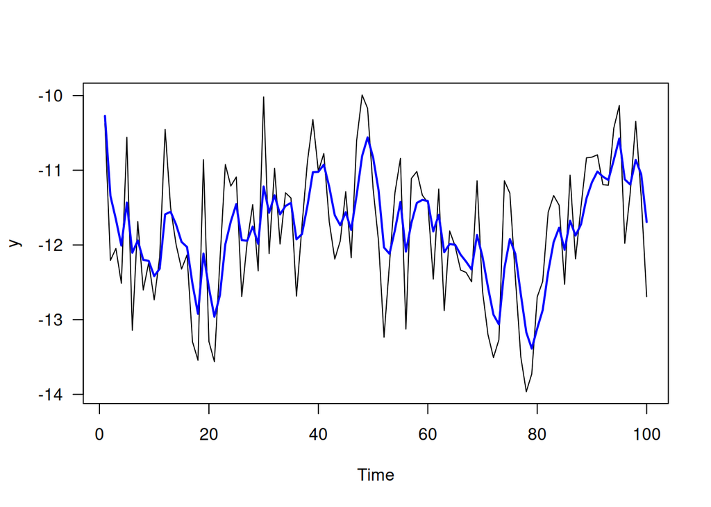

```r
plot.ts(y, las = 1)
lines(filt1$m[-1], col = "blue", lwd = 2)
```

## Maximum Likelihood

What if we did not know the parameter values (V, W)? Which is probably the reality most of the time.

The Kalman Filter can also be used to set up the likelihood, and then we can maximise this likelihood. This can be done using `dlmMLE()`, which sends the likelihood function to `optim()`. First we need to define the likelihood function. We also use the model definition functions for this, except that we substitute unknown parameter values for the variances. The first argument of the likelihood function must be the parameter vector. `parm` contains estimates for starting values for the parameters.

Both V and W need to be positive, therefore use exp(parm). This is a common trick used to obtain appropriate MLEs.

```r
# define the likelihood function
lik.fun <- function(x) {
 dlmModPoly(1, dV = exp(x[1]), dW = exp(x[2]))
}

# maximize the likelihood
fit <- dlmMLE(y, parm = c(0,0), build = lik.fun)

fit$conv
```

```
[1] 0
```

```r
fit
```

```
$par
[1] -0.4052241 -3.3573364

$value
[1] 49.29081

$counts
function gradient
      11       11

$convergence
[1] 0

$message
[1] "CONVERGENCE: REL_REDUCTION_OF_F <= FACTR*EPSMCH"
```

The object returned from `dlmMLE` is what is returned by `optim`. A code of 0 for convergence means success.

The variances (V and W) are estimated as

```r
exp(fit$par)
```

```
[1] 0.6668274 0.0348279
```

The true values were 0.8 and 0.2.

## Forecasting

Before you run the following code, or look at the output, predict what the forecasts will look like (we have fitted a random walk plus noise model).

```r
model.fit <- lik.fun(fit$par)
model.filtered <- dlmFilter(y, model.fit)

model.forecast <- dlmForecast(model.filtered, nAhead = 10)
str(model.forecast)
```

```
List of 4
 $ a: num [1:10, 1] -11.4 -11.4 -11.4 -11.4 -11.4 ...
 $ R:List of 10
  ..$ : num [1, 1] 0.171
  ..$ : num [1, 1] 0.206
  ..$ : num [1, 1] 0.24
  ..$ : num [1, 1] 0.275
  ..$ : num [1, 1] 0.31
  ..$ : num [1, 1] 0.345
  ..$ : num [1, 1] 0.38
  ..$ : num [1, 1] 0.415
  ..$ : num [1, 1] 0.449
  ..$ : num [1, 1] 0.484
 $ f: num [1:10, 1] -11.4 -11.4 -11.4 -11.4 -11.4 ...
 $ Q:List of 10
  ..$ : num [1, 1] 0.838
  ..$ : num [1, 1] 0.872
  ..$ : num [1, 1] 0.907
  ..$ : num [1, 1] 0.942
  ..$ : num [1, 1] 0.977
  ..$ : num [1, 1] 1.01
  ..$ : num [1, 1] 1.05
  ..$ : num [1, 1] 1.08
  ..$ : num [1, 1] 1.12
  ..$ : num [1, 1] 1.15
```

```r
plot.ts(y, xlim = c(0, 110), las = 1)
lines(x = 101:110, model.forecast$a, col = "purple", lwd = 2)
lines(filt1$m[-1], col = "blue", lwd = 2)
lines(model.filtered$m[-1], col = "orange", lwd = 2)

(pred.err <- unlist(model.forecast$R))
```

```
 [1] 0.1708005 0.2056284 0.2404563 0.2752842 0.3101122 0.3449401 0.3797680
 [8] 0.4145959 0.4494238 0.4842517
```

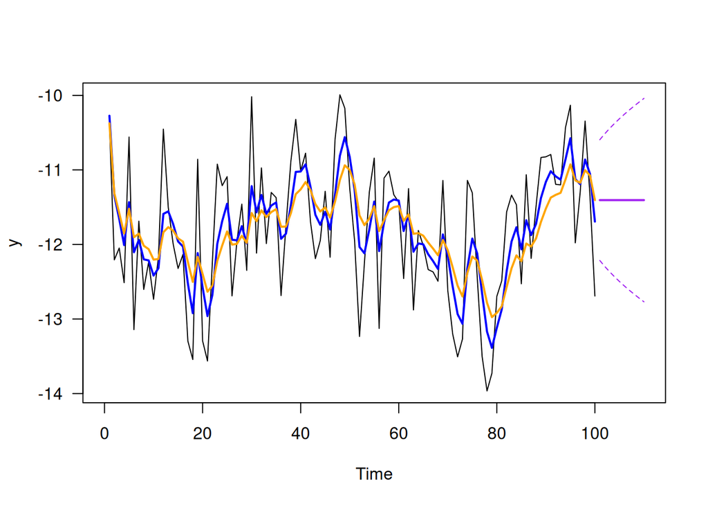

```r
lines(x = 101:110, model.forecast$a - 1.96 * sqrt(pred.err), col = "purple", lty = 2)
lines(x = 101:110, model.forecast$a + 1.96 * sqrt(pred.err), col = "purple", lty = 2)
```

Fit this same model to the Nile data.

# Local linear model

This can be set up as above or by just using `dlmModPoly`, whose default is the local linear model (`order` = 2).

```r
myMod <- dlmModPoly()
```

Up to you: repeat the above on the local linear model.

What happens with missing observaions?

# Seasonality - Basic Structural Model

We are going to fit the basic structural model to the monthly CO$_2$ data `co2`. This will have 12 seasonal effects.

$$\begin{align*}
Y_t &= \mu_t + s_t + v_t, \qquad & v_t \sim N(0, V) \\
\mu_t &= \mu_{t-1} + \beta_{t-1} + w_t, & w_t \sim N(0, \sigma_w^2) \\
\beta_t &= \beta_{t-1} + \gamma_t, & \gamma_t \sim N(0, \sigma^2_{\gamma})\\
\\
s_t &= - \sum_{j=1}^{S-1} s_{t-j} + \delta_t, & \delta_t \sim N(0, \sigma^2_{\delta}) \\
\end{align*}$$

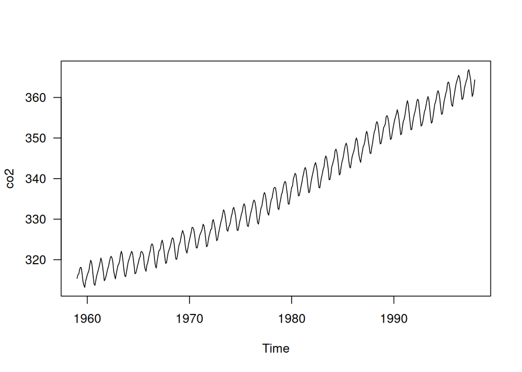

```r
plot(co2, las = 1)
```

We can use `dlmModSeas` to add these seasonal effects $s_{it}$.

```r
m.s1 <-  dlmModPoly() + dlmModSeas(12)
m.s1$W
```

```
      [,1] [,2] [,3] [,4] [,5] [,6] [,7] [,8] [,9] [,10] [,11] [,12] [,13]
 [1,]    0    0    0    0    0    0    0    0    0     0     0     0     0
 [2,]    0    1    0    0    0    0    0    0    0     0     0     0     0
 [3,]    0    0    1    0    0    0    0    0    0     0     0     0     0
 [4,]    0    0    0    0    0    0    0    0    0     0     0     0     0
 [5,]    0    0    0    0    0    0    0    0    0     0     0     0     0
 [6,]    0    0    0    0    0    0    0    0    0     0     0     0     0
 [7,]    0    0    0    0    0    0    0    0    0     0     0     0     0
 [8,]    0    0    0    0    0    0    0    0    0     0     0     0     0
 [9,]    0    0    0    0    0    0    0    0    0     0     0     0     0
[10,]    0    0    0    0    0    0    0    0    0     0     0     0     0
[11,]    0    0    0    0    0    0    0    0    0     0     0     0     0
[12,]    0    0    0    0    0    0    0    0    0     0     0     0     0
[13,]    0    0    0    0    0    0    0    0    0     0     0     0     0
```

Note: It seems that the default is to set $\sigma_w^2 = 0$ (first diagonal element of $W$).

## Define the likelihood function

We need to estimate the parameters (four variance parameters). The `exp(p[i])` trick is used to ensure the variance estimates are positive.

```r
lik.s1 <- function(p) {
  mod <- dlmModPoly() + dlmModSeas(12)

  W(mod)[1, 1] <- exp(p[1])
  W(mod)[2, 2] <- exp(p[2])
  W(mod)[3, 3] <- exp(p[3])

  V(mod) <- exp(p[4])

  return(mod)
}
```

Find MLEs:

```r
mle.s1 <- dlmMLE(co2, parm = c(0, 0, 0, 0), build = lik.s1, hessian = TRUE)
mle.s1
```

```
$par
[1]  -3.061164 -12.444946 -10.703485  -3.879932

$value
[1] -204.2741

$counts
function gradient
      30       30

$convergence
[1] 0

$message
[1] "CONVERGENCE: REL_REDUCTION_OF_F <= FACTR*EPSMCH"

$hessian
           [,1]         [,2]         [,3]        [,4]
[1,] 89.8219361 0.1860468295 0.7949725145 44.53769041
[2,]  0.1860468 0.5987007441 0.0008992345  0.02552982
[3,]  0.7949725 0.0008992345 0.1705986961  0.55405221
[4,] 44.5376904 0.0255298218 0.5540522068 44.71269065
```

`convergence = 0` means that the algorithm has converged.

Estimates of variance parameters:

```r
exp(mle.s1$par)
```

```
[1] 4.683313e-02 3.937575e-06 2.246651e-05 2.065222e-02
```

**Fitted values:**

```r
fit.s1 <- lik.s1(mle.s1$par)
fit.s1
```

```
$FF
     [,1] [,2] [,3] [,4] [,5] [,6] [,7] [,8] [,9] [,10] [,11] [,12] [,13]
[1,]    1    0    1    0    0    0    0    0    0     0     0     0     0

$V
           [,1]
[1,] 0.02065222

$GG
      [,1] [,2] [,3] [,4] [,5] [,6] [,7] [,8] [,9] [,10] [,11] [,12] [,13]
 [1,]    1    1    0    0    0    0    0    0    0     0     0     0     0
 [2,]    0    1    0    0    0    0    0    0    0     0     0     0     0
 [3,]    0    0   -1   -1   -1   -1   -1   -1   -1    -1    -1    -1    -1
 [4,]    0    0    1    0    0    0    0    0    0     0     0     0     0
 [5,]    0    0    0    1    0    0    0    0    0     0     0     0     0
```

[output cut: 71 more lines]

```r
filt.s1 <- dlmFilter(co2, fit.s1)

dim(filt.s1$m)
```

```
[1] 469  13
```

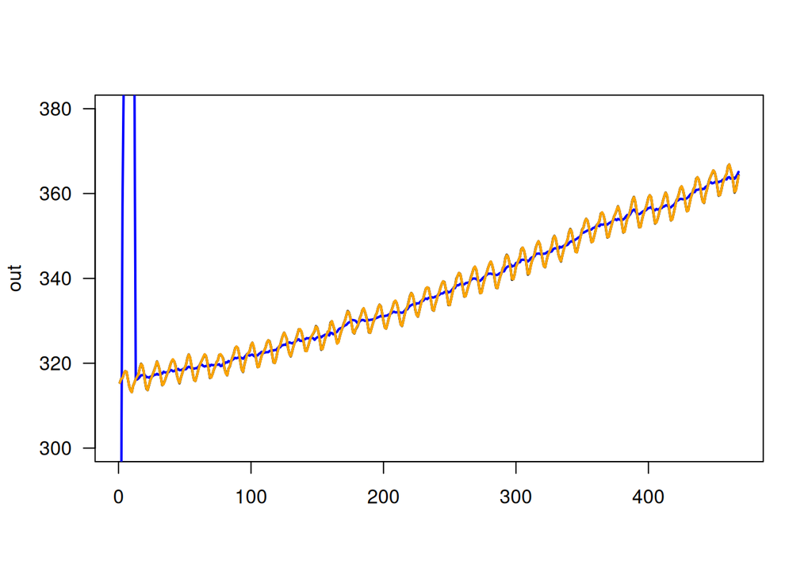

```r
out <- cbind(co2, filt.s1$m[-1, 1])
matplot(out, type = "l", ylim = c(300, 380), lty = 1, lwd = 2, col = c("black", "blue"),
        las = 1)
lines(filt.s1$m[-1, 1] + filt.s1$m[-1, 3], col = "orange", lwd = 2)
```

The blue line is the level only, observations in black. The orange line is obtained from the level plus seasonal effect *filtered* values.

Can you explain the strange blue lines at the beginning of the time series?

Can you add the *fitted* values to this plot?

Predictions for the next 5 years?

# Seasonality with trigonometric terms

An alternative way to add seasonality to state-space models is through cos and sin terms, like in a harmonic regression model.

$$\begin{align*}
Y_t &= \mu_t + g_t + v_t, \qquad & v_t \sim N(0, V) \\
\mu_t &= \mu_{t-1} + \beta_{t-1} + w_t, & w_t \sim N(0, \sigma_w^2) \\
\beta_t &= \beta_{t-1} + \gamma_t, & \gamma_t \sim N(0, \sigma^2_{\gamma})\\
\end{align*}$$

where

$g_t = a cos(t \omega) + b sin(t \omega)$

and $\omega$ is the frequency (in radians): $\omega = \frac{2 \pi }{s}$. $s$ is the period (length of a full cycle in terms of number of observations). This adds a sinusoidal curve to the seasona effects.

More generally, we define the Fourier frequencies as

$$\omega_j = \frac{2 \pi j}{s}$$

$s$ is the period (length of a full cycle in terms of number of observations). For $j=1$ a full cycle ($2 \pi$) is completed in $s$ time steps. For $j = 2$, two full cycles are completed in $s$ time steps ($4 \pi$).

To add more flexible seasonal patterns we could add terms with higher frequencies, $j = 0, 1, ..., \frac{s}{2}$,

Define the jth harmonic as

$$S_j(t) = a_j cos(t \omega_j) + b_j sin(t \omega_j)$$

and $g_t = \sum a_j cos(t \omega_j) + b_j sin(t \omega_j)$

The updating equation is a bit more complicated and needs the *conjugate harmonic*

$$S^*_j(t) = - a_j sin(t \omega_j) + b_j sin(t \omega_j)$$

In `dlm`, to add such harmonic terms to the state-space model we can use the function `dlmModTrig`:

```r
## first check if this is the structure we want
m.s1 <-  dlmModPoly() + dlmModTrig(s = 12, q = 1)
m.s1
```

```
$FF
     [,1] [,2] [,3] [,4]
[1,]    1    0    1    0

$V
     [,1]
[1,]    2

$GG
     [,1] [,2]       [,3]      [,4]
[1,]    1    1  0.0000000 0.0000000
[2,]    0    1  0.0000000 0.0000000
[3,]    0    0  0.8660254 0.5000000
[4,]    0    0 -0.5000000 0.8660254

$W
     [,1] [,2] [,3] [,4]
[1,]    0    0    0    0
[2,]    0    1    0    0
[3,]    0    0    0    0
[4,]    0    0    0    0

$m0
[1] 0 0 0 0

$C0
      [,1]  [,2]  [,3]  [,4]
[1,] 1e+07 0e+00 0e+00 0e+00
[2,] 0e+00 1e+07 0e+00 0e+00
[3,] 0e+00 0e+00 1e+07 0e+00
[4,] 0e+00 0e+00 0e+00 1e+07
```

$s$ is called period in this function, q is the number of harmonics to include.

period = time it takes to complete one cycle

frequency = number of cycles per unit time: $f = 1 / P$

Fit such a model to the CO$_2$ data and compare with the previous model. Do you need more than one harmonic?

How can you make the seasonal effect constant over time? Can you change this into a linear regression model with harmonic terms?